# Data Analysis for Job Positions

Dec 06 2020

The aim of this project is to explore jobs and try to find the common vocabulary used in the job description. Job type, company, title, location and description were analyzed below. For descriptions, texting manipulation was used to clean and dig the insight. I used two data sets, which the larger one is from Kaggle and another one is from Github.The data set which is from Github Job and, specifically jobs for software developers，data science. Linkis are https://jobs.github.com/api. The larger data set whcih is from Kaggle and jobs are from Australia.https://www.kaggle.com/vipulanand/jobs-data. Due to there are not many jobs posted on the Github(around 150), then I downloaded a larger data set from Kaggle to show the reproducibility of my code. I posted the larger data set in the repo as well. The code which is used to analysis are exactly same except the name of variable and attributes of job. The shiny App show the content from Github.

# 0. Import Packages

# 1. Data Ingest

```r
p1 = GET("https://jobs.github.com/positions.json?page=1")
p2 = GET("https://jobs.github.com/positions.json?page=2")
p3 = GET("https://jobs.github.com/positions.json?page=3")

p1 <- fromJSON(rawToChar(p1$content))
p2 <- fromJSON(rawToChar(p2$content))
p3 <- fromJSON(rawToChar(p3$content))

data <- rbind(p1, p2, p3)
names(data)
```

```
##  [1] "id"           "type"         "url"          "created_at"   "company"
##  [6] "company_url"  "location"     "title"        "description"  "how_to_apply"
## [11] "company_logo"
```

```r
glimpse(data)
```

```
## Rows: 150
## Columns: 11
## $ id           <chr> "46ab84b4-12dc-4a95-ab08-422428554dfc", "bead9090-4ebb-4…
## $ type         <chr> "Full Time", "Full Time", "Full Time", "Full Time", "Ful…
## $ url          <chr> "https://jobs.github.com/positions/46ab84b4-12dc-4a95-ab…
## $ created_at   <chr> "Fri Oct 09 19:42:30 UTC 2020", "Fri Oct 30 03:52:17 UTC…
## $ company      <chr> "Playco", "Agiloft Inc", "Agiloft Inc", "Agiloft, Inc.",…
## $ company_url  <chr> "http://www.play.co", "http://www.agiloft.com", "http://…
## $ location     <chr> "Remote", "Kyiv, Ukraine, Budapest, Hungary, Russia", "K…
## $ title        <chr> "Senior Fullstack Engineer", " Senior EJB Developer (Rem…
## $ description  <chr> "<p>Here at Playco, we make games that bring the world c…
## $ how_to_apply <chr> "<p><a href=\"https://jobs.lever.co/playco/453d2258-7e66…
## $ company_logo <chr> "https://jobs.github.com/rails/active_storage/blobs/eyJf…
```

```r
df <- data %>% select(id, type, company, location, title, description)
df <- as.data.frame(df)
df %>% head() %>% as.tibble() %>% view()
```

# 2. Exploratory Data Analysis

## 2.1 Missing Value

There is no missing existing in the data set.

```r
missing_col<-df %>% is.na() %>% colSums()
  missing_col <- data.frame(missing_col) %>% rownames_to_column()
  missing_df <- missing_col %>%
    mutate(Percentage_of_Missing=missing_col/nrow(df)*100) %>% arrange(desc(Percentage_of_Missing))
print(missing_df)
```

```
##       rowname missing_col Percentage_of_Missing
## 1          id           0                     0
## 2        type           0                     0
## 3     company           0                     0
## 4    location           0                     0
## 5       title           0                     0
## 6 description           0                     0
```

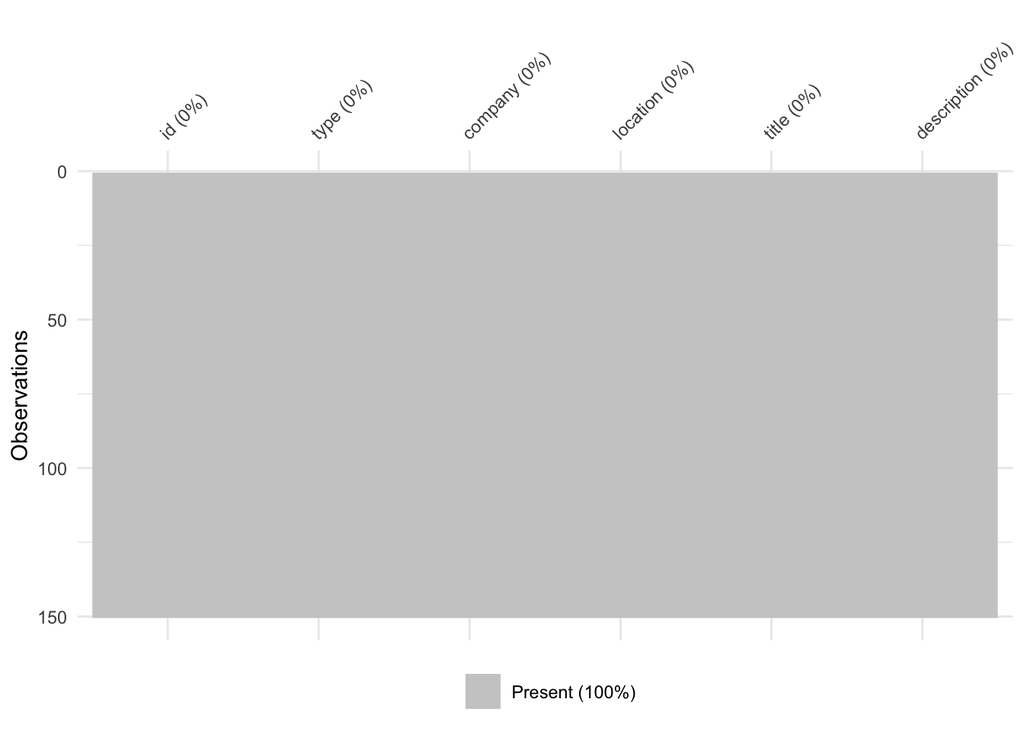

```r
vis_miss(df)
```

## 2.2 Summary for Type, Company, Title and Location

```r
df %>% summarise(distinct_type=n_distinct(type), distinct_company=n_distinct(company),distinct_title=n_distinct(title), distinct_lication=n_distinct(location))
```

```
##   distinct_type distinct_company distinct_title distinct_lication
## 1             2              113            141                91
```

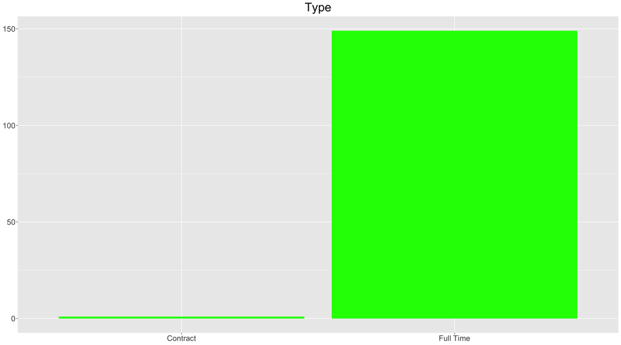

```r
type_bar <- ggplot(df, aes(x=type)) +
            geom_bar(fill="green") +
            theme(axis.title.x = element_blank(), axis.title.y = element_blank(),
                  legend.position = "none", plot.title = element_text(hjust = 0.5, size=25), text = element_text(size=20)) + ggtitle("Type")
company_bar <- ggplot(df %>% group_by(company) %>% summarise(count_company=n()) %>% arrange(-count_company) %>% head(5), aes(x=reorder(company, count_company), y=count_company)) +
            geom_bar(stat="identity", fill="darkred") +coord_flip()+
            theme(axis.title.x = element_blank(), axis.title.y = element_blank(),
                  legend.position = "none", plot.title = element_text(hjust = 0.5, size=25), text = element_text(size=20)) + ggtitle("Company")
title_bar <- ggplot(df %>% group_by(title) %>% summarise(count_title=n()) %>% arrange(-count_title) %>% head(5), aes(x=reorder(title, count_title), y=count_title)) +
            geom_bar(stat="identity", fill="purple") +coord_flip()+
            theme(axis.title.x = element_blank(), axis.title.y = element_blank(),
                  legend.position = "none", plot.title = element_text(hjust = 0.5, size=25), text = element_text(size=20)) + ggtitle("Title")
location_bar <- ggplot(df %>% group_by(location) %>% summarise(count_location=n()) %>% arrange(-count_location) %>% head(5), aes(x=reorder(location, count_location), y=count_location))+
           geom_bar(stat="identity", fill="steelblue") + coord_flip()+
           theme(axis.title.x = element_blank(), axis.title.y = element_blank(),
                  legend.position = "none", plot.title = element_text(hjust = 0.5, size=25), text = element_text(size=20)) + ggtitle("Location")
type_bar
```

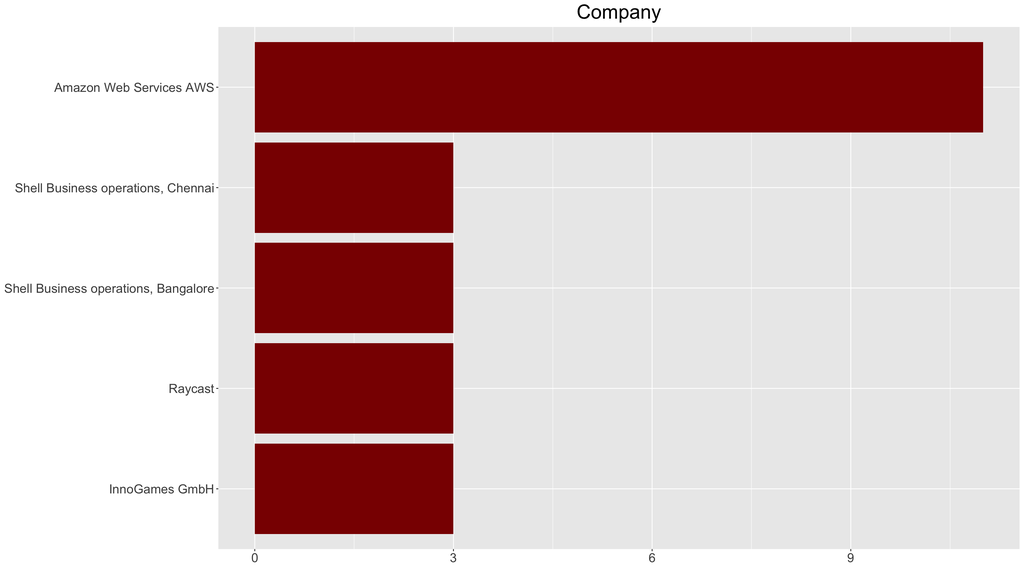

```r
company_bar
```

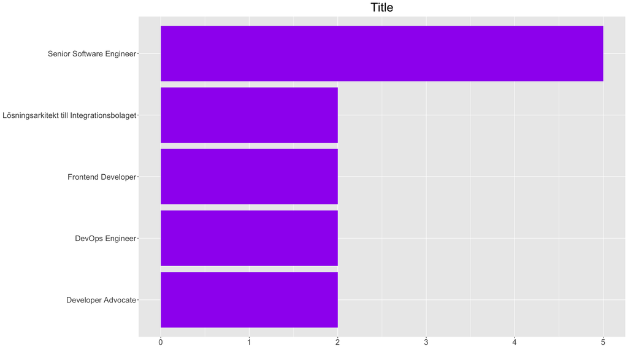

```r
title_bar
```

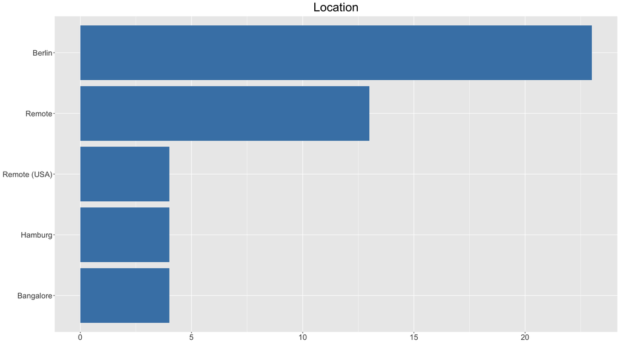

```r
location_bar
```

## 2.3 Description

### 2.3.1 Common words

First, check the top 20 common words in job description. From plot below, there are some html decoration words which are from websites existing. Besides those html format words, strong, work, experience, data and etc. are the most common words in the descriptions.

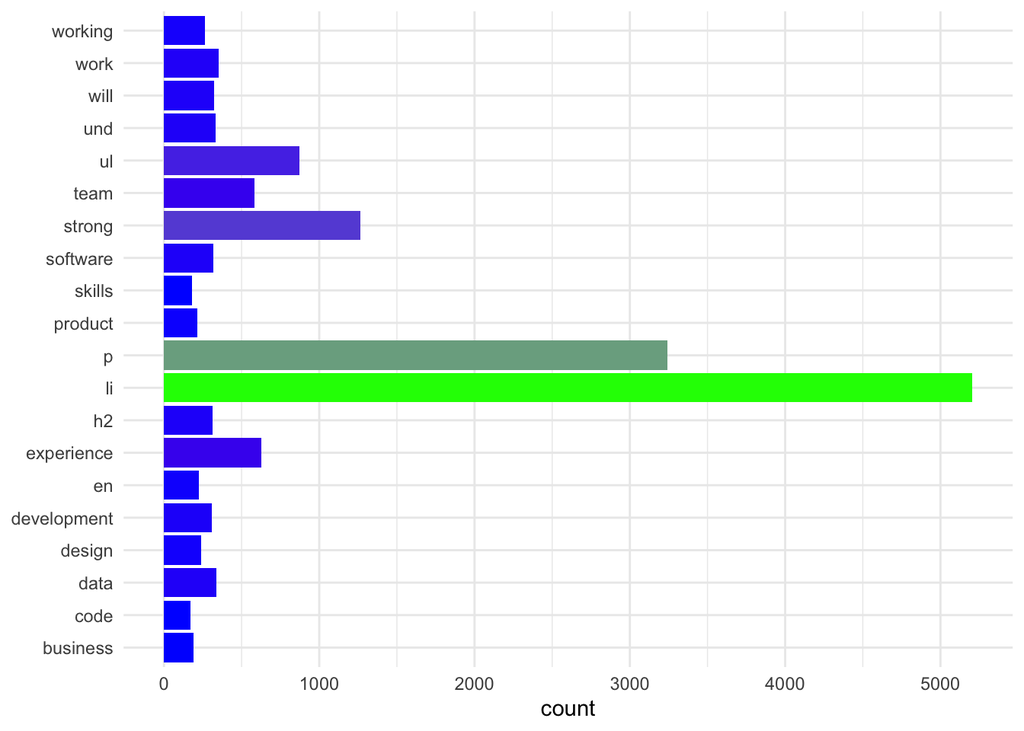

```r
STOPWORDS <- stopwords(kind = "en")
generate_cm_wd <- function(ccc){
  words <- paste(ccc, collapse = " ")
  words <- tokenize_words(words)
  tab <- table(words[[1]])
  tab <- data_frame(word = names(tab), count = as.numeric(tab))
  tab <- tab %>% filter(!word %in% STOPWORDS) %>% arrange(desc(count)) %>% head(20)
  return(tab)
}

df_cm_wd <- generate_cm_wd(df$description)
df_cmwd_bar<-ggplot(data=df_cm_wd, aes(x=word, y=count, fill=count)) +
  geom_bar(stat="identity")+coord_flip()+
  scale_fill_continuous(low="blue", high="green")+
  theme_minimal() +theme(axis.title.y = element_blank(),
                          legend.position = "none")
df_cmwd_bar
```

### 2.3.2 Number of words in each job description and Average length for each job description

Most job descriptions contain between 250 and 800 words. The distribution is little bit right skewed. Job descriptions with more than 1000 words are less than 5.

Average words in the description is right skewed

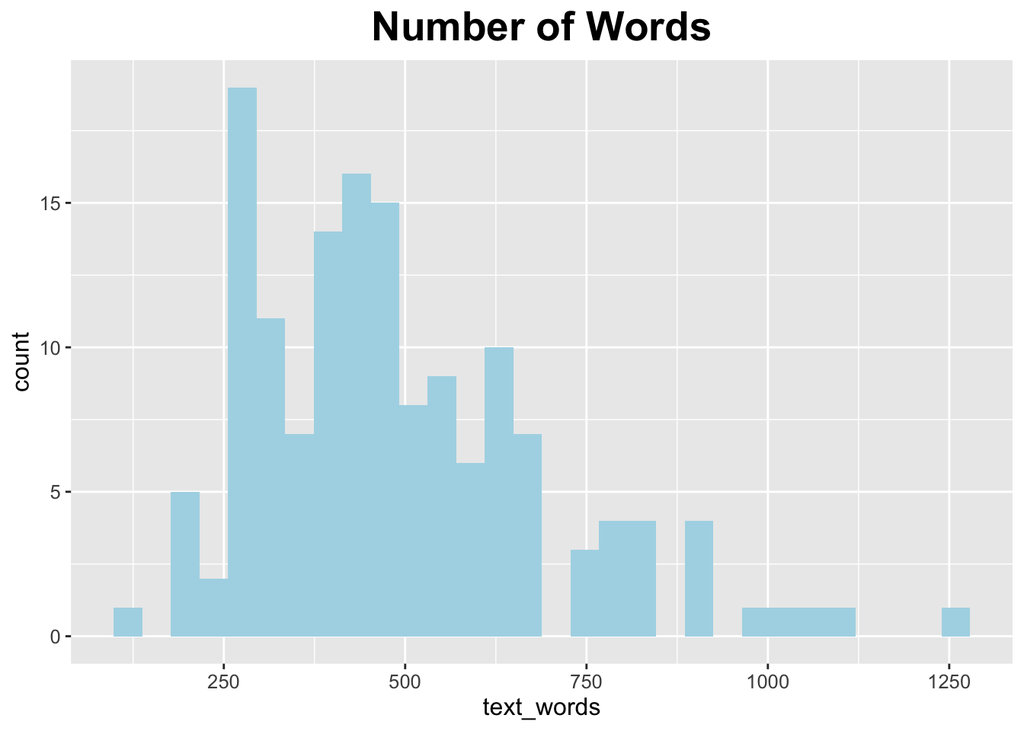

```r
df <- df %>% mutate(text_words = sapply(strsplit(df$description, " "), length))
df <- df %>% mutate(text_len = str_count(description))
df <- df %>% mutate(text_avg_words = text_len/text_words)

# Number of words
num_words <- ggplot(df, aes(x=text_words)) +
            geom_histogram(fill="lightblue") +
            theme(legend.position = "none", plot.title = element_text(size = 20, face = "bold", hjust = 0.5), text = element_text(size=12)) + ggtitle("Number of Words")
# Average words
ave_words <- ggplot(df, aes(x=text_avg_words)) +
            geom_density(fill="lightblue") +
            theme(legend.position = "none", plot.title = element_text(size = 20, face = "bold", hjust = 0.5), text = element_text(size=12)) + ggtitle("Average Length of Words")


num_words
```

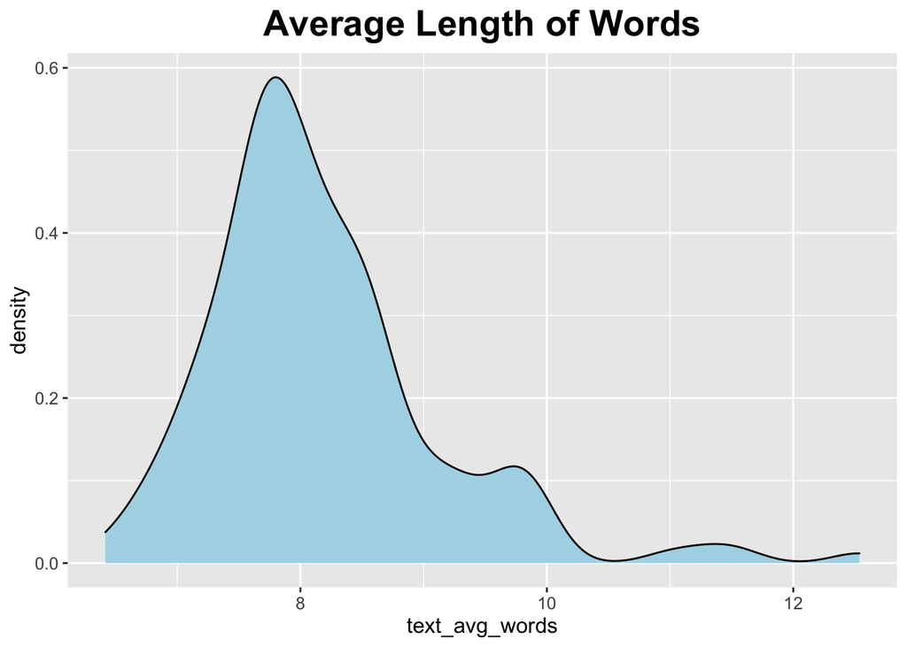

```r
ave_words
```

### 2.3.3 Clean text and word cloud

```r
stopwords_regex = paste(stopwords('en'), collapse = '\\b|\\b')
stopwords_regex = paste0('\\b', stopwords_regex, '\\b')
df$description<- str_replace_all(df$description, stopwords_regex, '')
df$description <- str_replace_all(df$description, regex('[:punct:]'), "")
df$description <- str_replace_all(df$description, regex('[:digit:]'), "")
df$description <- str_replace_all(df$description, regex('<p>'), " ")
df$description <- str_replace_all(df$description, regex('und'), " ")
df$description <- str_replace_all(df$description, regex('</p>'), " ")
df$description <- str_replace_all(df$description, regex('will'), " ")
df$description <- str_replace_all(df$description, regex('you'), "")
df$description <- str_replace_all(df$description, regex('the'), "")
df$description <- str_to_lower(df$description, locale = 'en')
description <- Corpus(VectorSource(df %>% select(description)))
desp <- description %>%
    tm_map(removeNumbers) %>%
    tm_map(removePunctuation) %>%
    tm_map(removeWords, stopwords("english")) %>%
    tm_map(stripWhitespace)
desp <- tm_map(desp, content_transformer(tolower))
```

```r
desp <- TermDocumentMatrix(desp)
matrix <- as.matrix(desp)
words <- sort(rowSums(matrix),decreasing=TRUE)
pre_words <- data.frame(word = names(words),freq=words)


clean_desp <- wordcloud2(pre_words, size=1.6, color='random-dark')+ WCtheme(1)
clean_desp
```

[interactive chart not shown]

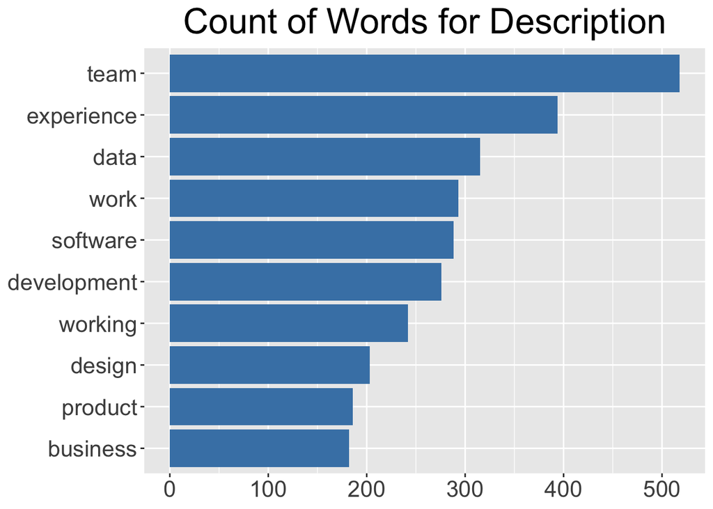

```r
ggplot(pre_words %>% head(10), aes(x=reorder(word, freq), y=freq)) +
                    geom_bar(stat="identity", fill="steelblue")+coord_flip()+
                    theme(axis.title.x = element_blank(), axis.title.y = element_blank(),
                          legend.position = "none", plot.title = element_text(hjust = 0.5, size=25), text = element_text(size=20))+ ggtitle("Count of Words for Description")
```